# EDA - 6813

Andrew Walton

2024-02-18

# Introduction

## Purpose of EDA

Explore the data set that we have been given and familiarize ourselves with some of the trends and patterns within the data. We have broken the EDA portion of this project into multiple sections, such as general insights, product insights, and demographic insights.

Exploring the data and becoming familiar with the data that we are working with will help us to build the best possible models with the most accuracy

## Business Problem

Swire Coca-Cola is a large organization that produces, sells and distributes Coca-Cola and other beverages in 13 states across the American West.

While the demand for Swire’s core products is relatively know, they also introduce new and innovative products on a regular basis. These products are often “limited time only” products meant to drive demand. Swire Coca-Cola needs to accurately predict demand for their innovative products. Historical data from other projects can help but will not provide a fully accurate prediction as each product is different and will target different regions, demographics, etc. The purpose of the project is to use the available demographic and historical product data to accurately predict demand of future innovation products.

## Analytics Problem

There are a few analytics problems that we will need to solve as part of this project.

First, we need to decided what to do with the data currently outside of the main market demand data frame. We have demographic data and zip code data in separate data frames and we will likely need to utilize this to accurately forecast demand in certain regions or for certain demographics. For the questions related specifically to certain regions, we will need to incorporate that data to make accurate predictions.

Second, we have historical data but the historical data we have includes products released for varying time frames. Equally, our products that we need to forecast for also have varying time frames, such as 13 weeks, 6 months, etc. We will try and use the historical data for the time periods that match to answer those questions

## Success Metrics

Success will be determined by our ability to provide accurate forecasts that allow Swire to accurately provide supply to meet demand, without leaving leftover products in supply while also not leaving any demand unserved. Our success will be determined by the financial impact that our predictions will have on the company’s profit, which we will calculate using our model and some industry standard metrics.

# Description of the Data

We have 3 data sets that are available to build our model, and each will be crucial in leveraging when building our models.

The first data set is the Market Demand which includes historical data of past products. These products include various categories, brands, caloric segments, and packaging. We have over 24 million rows of this data, so we need to factor in the size of the data and how we will account for this.

The second data set is a demographics sheet. This includes various demographic information such as age, income, gender, household income, and segment. We can utilize this to forecast sales in areas that have similar demographics.

Lastly, we have zip code information that will allow us to map the historical sales data to specific zip codes.

# Discussion of Missing Data

There were some NAs which were imputed by Jake and as a team we are now using a data set that does not include missing data

# EDA

## Loading Libraries and Data Set

> Converting many of the chr columns to factors as well as formatting the date column as a date

> Creating a new column which is called UNIT_PRICE by dividing the total amount sold in dollars by the total amount of units sold

## Summary of Data Set and Columns

```r
summary(swire_df)
```

```
##       DATE              MARKET_KEY         CALORIC_SEGMENT
##  Min.   :2020-12-05   1811   :  198609   DIET/LIGHT:12174588
##  1st Qu.:2021-08-14   1172   :  185475   REGULAR   :12286836
##  Median :2022-04-23   6802   :  159909
##  Mean   :2022-04-25   602    :  146398
##  3rd Qu.:2022-12-31   1135   :  145933
##  Max.   :2023-10-28   117    :  141489
##                       (Other):23483611
##                CATEGORY          UNIT_SALES        DOLLAR_SALES
##  COFFEE            :  145536   Min.   :    0.04   Min.   :     0.0
##  ENERGY            : 5932087   1st Qu.:   11.00   1st Qu.:    36.6
##  ING ENHANCED WATER: 2452456   Median :   40.00   Median :   135.1
##  SPARKLING WATER   : 3019064   Mean   :  174.37   Mean   :   591.1
##  SSD               :12912281   3rd Qu.:  126.00   3rd Qu.:   427.1
##                                Max.   :96776.00   Max.   :492591.1
##
##    MANUFACTURER                         BRAND
##  JOLLYS  :6921978   CROWN                  : 1239010
##  SWIRE-CC:5763809   REAL-TIME EDITIONS     :  827868
##  COCOS   :5595540   DIGRESS FLAVORED       :  731199
##  PONYS   :2259095   MYTHICAL BEVERAGE ULTRA:  718536
##  BEARS   :1593430   BUBBLE JOY             :  535030
##  ALLYS   :1428416   REAL-TIME              :  531911
##  (Other) : 899156   (Other)                :19877870
##               PACKAGE             ITEM             UNIT_PRICE
##  16SMALL MULTI CUP: 3065844   Length:24461424    Min.   :  0.00333
##  20SMALL MULTI JUG: 2877015   Class :character   1st Qu.:  2.00429
##  12SMALL 12ONE CUP: 2870763   Mode  :character   Median :  3.18000
##  2L MULTI JUG     : 1896248                      Mean   :  4.52689
##  .5L 6ONE JUG     : 1453399                      3rd Qu.:  5.34105
##  12SMALL 8ONE CUP : 1408738                      Max.   :224.99000
##  (Other)          :10889417
```

> We have a few outliers that we may want to consider exploring here:

> UNIT_PRICE: The Max Unit Price seems very high compared to the rest of the observations, and I don’t see an explanation for this as there doesn’t seem to be any products in the data set that should sell for that price

> UNIT_SALES: The Max Unit Sales seems very high compared to the rest of the observations. This could be that they have a certain product that is very popular (such as regular coke, diet coke, pepsi, etc) included in the data set, but it would be worth exploring

## Exploratory Visualizations and Summary Tables

### Takeaway 1: Average Price Per Unit

```r
brand_ppu_summary <- swire_df %>%
  group_by(BRAND) %>%
  summarise(n = n(),
            avg_price_unit = mean(UNIT_PRICE),
            avg_sales_dollars = mean(DOLLAR_SALES),
            avg_unit_sales = mean(UNIT_SALES)
  ) %>%
  arrange(desc(avg_price_unit)) %>%
  head(10)

brand_ppu_summary
```

```
## # A tibble: 10 × 5
##    BRAND                       n avg_price_unit avg_sales_dollars avg_unit_sales
##    <fct>                   <int>          <dbl>             <dbl>          <dbl>
##  1 ALL-OUT ALLIGATOR REA…  11545          35.1               101.           2.32
##  2 KEKE ENERGY ENERGY EX… 263320          15.9               423.          74.5
##  3 KEKE ENERGY ENERGY OR… 207666          13.5               155.          23.9
##  4 CUPADA ARID REMAINING     488          11.5               763.          66.4
##  5 REAL-TIME              531911          11.1              1950.         505.
##  6 MYTHICAL BEVERAGE ABG…  56240          10.9               544.         173.
##  7 MYTHICAL BEVERAGE LO … 142432          10.5               482.         127.
##  8 MEXICAN BUBBLE JOY AD…  85034           7.69              675.         206.
##  9 MYTHICAL BEVERAGE ULT… 718536           7.60              695.         206.
## 10 MYTHICAL BEVERAGE      271932           7.26             1702.         521.
```

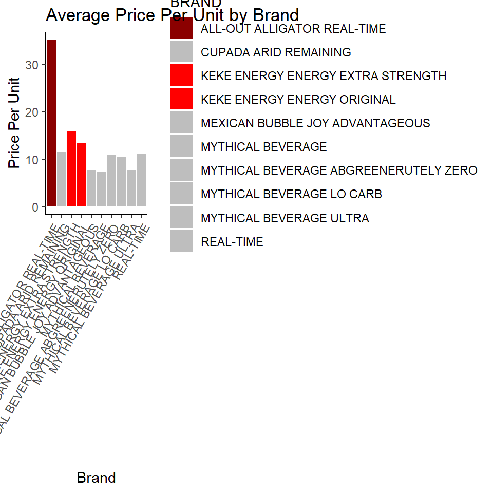

```r
ggplot(brand_ppu_summary, aes(x = BRAND )) +
  geom_bar(aes(y = avg_price_unit, fill = BRAND), stat = "identity", position = "dodge") +
  labs(title = "Average Price Per Unit by Brand",
       x = "Brand",
       y = "Price Per Unit") +
   scale_fill_manual(values = c("ALL-OUT ALLIGATOR REAL-TIME" = "darkred", "KEKE ENERGY ENERGY EXTRA STRENGTH" = "red", "KEKE ENERGY ENERGY ORIGINAL" = "red", "CUPADA ARID REMAINING" = "grey", "REAL-TIME" = "grey", "MYTHICAL BEVERAGE ABGREENERUTELY ZERO" = "grey", "MYTHICAL BEVERAGE LO CARB" = "grey", "MEXICAN BUBBLE JOY ADVANTAGEOUS" = "grey", "MYTHICAL BEVERAGE ULTRA" = "grey", "MYTHICAL BEVERAGE" = "grey")) +
  theme_classic() +
  theme(axis.text.x = element_text(angle = 60, hjust = 1)) +
  theme(axis.text.y = element_text(angle = 0, hjust = 1))
```

> We have a few products that seem to have a much higher avg_price_unit than the mean ($4.50). This includes one product with and average price of $35 and then another tier of products with average prices between $10-$15. These products may not need to sell as many units to be able to reach a high number of total sales dollars due to the high prices associated with the products

### Takeaway 2: Large Total Dollar Sales

```r
brand_summary <- swire_df %>%
  group_by(BRAND) %>%
  summarise(n = n(),
            total_sales_dollars = sum(DOLLAR_SALES),
            total_unit_sales = sum(UNIT_SALES)
  ) %>%
  arrange(desc(total_sales_dollars)) %>%
  head(10)

brand_summary
```

```
## # A tibble: 10 × 4
##    BRAND                             n total_sales_dollars total_unit_sales
##    <fct>                         <int>               <dbl>            <dbl>
##  1 BUBBLE JOY ADVANTAGEOUS      443625         1604866764.       404310942.
##  2 REAL-TIME                    531911         1037072280.       268351647.
##  3 PEPPY                        399458          937030445.       251184816.
##  4 PAPI                         454567          816413505.       216457130.
##  5 DIET BUBBLE JOY ADVANTAGEOUS 369807          653091204.       168687013.
##  6 ELF BUBBLES                  402084          649144309.       177671835.
##  7 HILL MOISTURE                505286          557565468.       167352606.
##  8 REAL-TIME EDITIONS           827868          514215183.       172718827.
##  9 MYTHICAL BEVERAGE ULTRA      718536          499397532.       147757133.
## 10 MYTHICAL BEVERAGE            271932          462803408.       141581921.
```

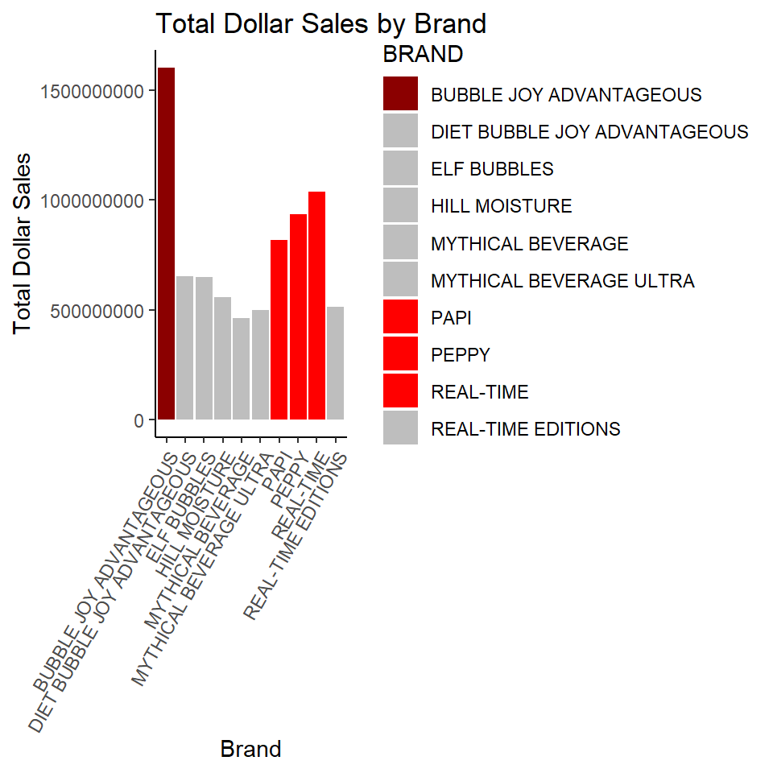

```r
ggplot(brand_summary, aes(x = BRAND )) +
  geom_bar(aes(y = total_sales_dollars, fill = BRAND), stat = "identity", position = "dodge") +
  labs(title = "Total Dollar Sales by Brand",
       x = "Brand",
       y = "Total Dollar Sales") +
   scale_fill_manual(values = c("BUBBLE JOY ADVANTAGEOUS" = "darkred", "REAL-TIME" = "red", "PEPPY" = "red", "PAPI" = "red", "DIET BUBBLE JOY ADVANTAGEOUS" = "grey", "ELF BUBBLES" = "grey", "HILL MOISTURE" = "grey", "REAL-TIME EDITIONS" = "grey", "MYTHICAL BEVERAGE ULTRA" = "grey", "MYTHICAL BEVERAGE" = "grey")) +
  theme_classic() +
  theme(axis.text.x = element_text(angle = 60, hjust = 1)) +
  theme(axis.text.y = element_text(angle = 0, hjust = 1))
```

> We have multiple brands exceeding $1B in total sales dollars, and quite a few more above $500M. We are obviously dealing with very large and well known brands in this data set.

### Takeaway 3: Manufacturers Average Sales

```r
man_avg_summary <- swire_df %>%
  group_by(MANUFACTURER) %>%
  summarise(n = n(),
            avg_price_unit = mean(UNIT_PRICE),
            avg_sales_dollars = mean(DOLLAR_SALES),
            avg_unit_sales = mean(UNIT_SALES)
  ) %>%
  arrange(desc(avg_sales_dollars))

man_avg_summary
```

```
## # A tibble: 8 × 5
##   MANUFACTURER       n avg_price_unit avg_sales_dollars avg_unit_sales
##   <fct>          <int>          <dbl>             <dbl>          <dbl>
## 1 ALLYS        1428416           8.26             1094.          312.
## 2 COCOS        5595540           3.92              816.          229.
## 3 PONYS        2259095           6.19              656.          210.
## 4 SWIRE-CC     5763809           3.76              501.          145.
## 5 JORDYS        428170           5.45              489.          188.
## 6 JOLLYS       6921978           3.82              477.          151.
## 7 KEKES         470986          14.8               305.           52.2
## 8 BEARS        1593430           3.50              196.           51.4
```

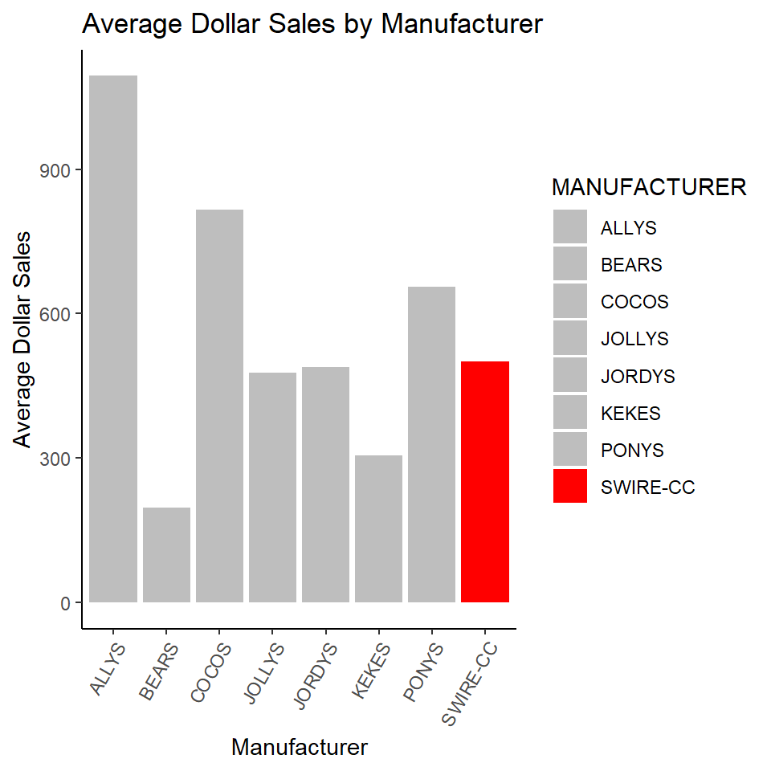

```r
ggplot(man_avg_summary, aes(x = MANUFACTURER )) +
  geom_bar(aes(y = avg_sales_dollars, fill = MANUFACTURER), stat = "identity", position = "dodge") +
  labs(title = "Average Dollar Sales by Manufacturer",
       x = "Manufacturer",
       y = "Average Dollar Sales") +
  scale_fill_manual(values = c("SWIRE-CC" = "red", "JOLLYS" = "grey", "COCOS" = "grey", "ALLYS" = "grey", "PONYS" = "grey", "BEARS" = "grey", "JORDYS" = "grey", "KEKES" = "grey")) +
  theme_classic() +
  theme(axis.text.x = element_text(angle = 60, hjust = 1)) +
  theme(axis.text.y = element_text(angle = 0, hjust = 1))
```

> They are doing much better in terms of average sales when compared to BEARS and KEKES.

### Takeaway 4: Manufacturers Total Sales

```r
man_ts_summary <- swire_df %>%
  group_by(MANUFACTURER) %>%
  summarise(n = n(),
            total_sales_dollars = sum(DOLLAR_SALES),
            total_unit_sales = sum(UNIT_SALES)
  ) %>%
  arrange(desc(total_sales_dollars))

man_ts_summary
```

```
## # A tibble: 8 × 4
##   MANUFACTURER       n total_sales_dollars total_unit_sales
##   <fct>          <int>               <dbl>            <dbl>
## 1 COCOS        5595540         4563306476.      1279323647.
## 2 JOLLYS       6921978         3301641671.      1043704245.
## 3 SWIRE-CC     5763809         2885435787.       834941867.
## 4 ALLYS        1428416         1562675378.       445086050.
## 5 PONYS        2259095         1481611289.       475149320.
## 6 BEARS        1593430          312718094.        81974082.
## 7 JORDYS        428170          209238104.        80589148.
## 8 KEKES         470986          143501825.        24594243.
```

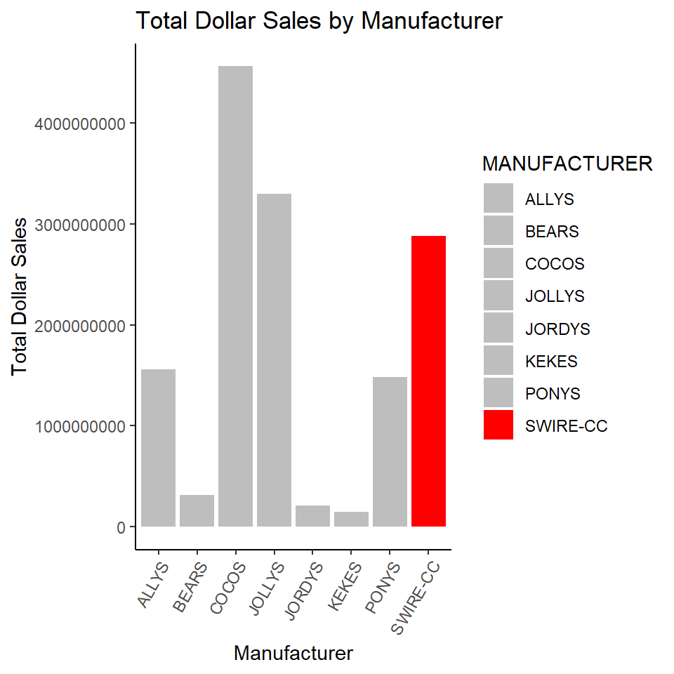

```r
ggplot(man_ts_summary, aes(x = MANUFACTURER )) +
  geom_bar(aes(y = total_sales_dollars, fill = MANUFACTURER), stat = "identity", position = "dodge") +
  labs(title = "Total Dollar Sales by Manufacturer",
       x = "Manufacturer",
       y = "Total Dollar Sales") +
  scale_fill_manual(values = c("SWIRE-CC" = "red", "JOLLYS" = "grey", "COCOS" = "grey", "ALLYS" = "grey", "PONYS" = "grey", "BEARS" = "grey", "JORDYS" = "grey", "KEKES" = "grey")) +
  theme_classic() +
  theme(axis.text.x = element_text(angle = 60, hjust = 1)) +
  theme(axis.text.y = element_text(angle = 0, hjust = 1))
```

### Takeaway 5: Manufacturers Average Unit Price

```r
man_up_summary<- swire_df %>%
  group_by(MANUFACTURER) %>%
  summarise(n = n(),
            total_sales_dollars = sum(DOLLAR_SALES),
            average_unit_price = mean(UNIT_PRICE)
  ) %>%
  arrange(desc(average_unit_price))

man_up_summary
```

```
## # A tibble: 8 × 4
##   MANUFACTURER       n total_sales_dollars average_unit_price
##   <fct>          <int>               <dbl>              <dbl>
## 1 KEKES         470986          143501825.              14.8
## 2 ALLYS        1428416         1562675378.               8.26
## 3 PONYS        2259095         1481611289.               6.19
## 4 JORDYS        428170          209238104.               5.45
## 5 COCOS        5595540         4563306476.               3.92
## 6 JOLLYS       6921978         3301641671.               3.82
## 7 SWIRE-CC     5763809         2885435787.               3.76
## 8 BEARS        1593430          312718094.               3.50
```

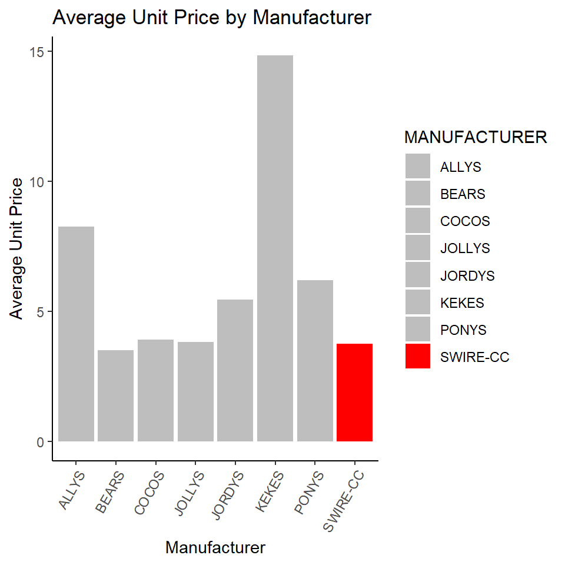

```r
ggplot(man_up_summary, aes(x = MANUFACTURER )) +
  geom_bar(aes(y = average_unit_price, fill = MANUFACTURER), stat = "identity", position = "dodge") +
  labs(title = "Average Unit Price by Manufacturer",
       x = "Manufacturer",
       y = "Average Unit Price") +
  scale_fill_manual(values = c("SWIRE-CC" = "red", "JOLLYS" = "grey", "COCOS" = "grey", "ALLYS" = "grey", "PONYS" = "grey", "BEARS" = "grey", "JORDYS" = "grey", "KEKES" = "grey")) +
  theme_classic() +
  theme(axis.text.x = element_text(angle = 60, hjust = 1)) +
  theme(axis.text.y = element_text(angle = 0, hjust = 1))
```

> The average unit price has a large range when grouped by manufacturers, and SWIRE-CC is unfortunately near the bottom of this list. KEKES, ALLYS, and PONYS all do significantly less total dollar sales and total unit sales than SWIRE-CC, but all 3 are selling their units at a much higher price.

### Takeaway 6: Caloric Segment

```r
man_cs_summary <- swire_df %>%
  group_by(CALORIC_SEGMENT) %>%
  summarise(n = n(),
            avg_price_unit = mean(UNIT_PRICE),
            avg_sales_dollars = mean(DOLLAR_SALES),
            avg_unit_sales = mean(UNIT_SALES),
            total_sales_dollars = sum(DOLLAR_SALES)
  ) %>%
  arrange(desc(avg_sales_dollars))

man_cs_summary
```

```
## # A tibble: 2 × 6
##   CALORIC_SEGMENT        n avg_price_unit avg_sales_dollars avg_unit_sales
##   <fct>              <int>          <dbl>             <dbl>          <dbl>
## 1 REGULAR         12286836           4.29              739.           220.
## 2 DIET/LIGHT      12174588           4.77              442.           128.
## # ℹ 1 more variable: total_sales_dollars <dbl>
```

```r
swire_df %>%
  group_by(CALORIC_SEGMENT) %>%
  summarise(n = n(),
            total_sales_dollars = sum(DOLLAR_SALES),
            total_unit_sales = sum(UNIT_SALES)
  ) %>%
  arrange(desc(total_sales_dollars))
```

```
## # A tibble: 2 × 4
##   CALORIC_SEGMENT        n total_sales_dollars total_unit_sales
##   <fct>              <int>               <dbl>            <dbl>
## 1 REGULAR         12286836         9081956949.      2702820349.
## 2 DIET/LIGHT      12174588         5378171675.      1562542253.
```

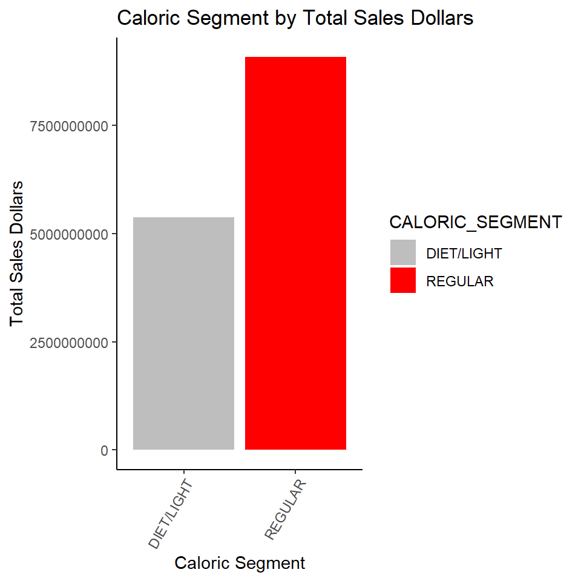

```r
ggplot(man_cs_summary, aes(x = CALORIC_SEGMENT )) +
  geom_bar(aes(y = total_sales_dollars, fill = CALORIC_SEGMENT), stat = "identity", position = "dodge") +
  labs(title = "Caloric Segment by Total Sales Dollars",
       x = "Caloric Segment",
       y = "Total Sales Dollars") +
  theme_classic() +
  scale_fill_manual(values = c( "DIET/LIGHT" = "grey", "REGULAR" = "red")) +
  theme(axis.text.x = element_text(angle = 60, hjust = 1)) +
  theme(axis.text.y = element_text(angle = 0, hjust = 1))
```

### Takeaway 7: Category SSD is by far the biggest category

```r
cat_summary <- swire_df %>%
  group_by(CATEGORY) %>%
  summarise(n = n(),
            avg_price_unit = mean(UNIT_PRICE),
            avg_sales_dollars = mean(DOLLAR_SALES),
            avg_unit_sales = mean(UNIT_SALES),
            total_sales_dollars = sum(DOLLAR_SALES)
  ) %>%
  arrange(desc(avg_sales_dollars))

cat_summary
```

```
## # A tibble: 5 × 6
##   CATEGORY                  n avg_price_unit avg_sales_dollars avg_unit_sales
##   <fct>                 <int>          <dbl>             <dbl>          <dbl>
## 1 SSD                12912281           3.91             744.           209.
## 2 ENERGY              5932087           6.60             627.           202.
## 3 SPARKLING WATER     3019064           3.74             208.            55.0
## 4 ING ENHANCED WATER  2452456           3.80             202.            80.4
## 5 COFFEE               145536           2.91              99.0           45.1
## # ℹ 1 more variable: total_sales_dollars <dbl>
```

```r
swire_df %>%
  group_by(CATEGORY) %>%
  summarise(n = n(),
            total_sales_dollars = sum(DOLLAR_SALES),
            total_unit_sales = sum(UNIT_SALES)
  ) %>%
  arrange(desc(total_sales_dollars))
```

```
## # A tibble: 5 × 4
##   CATEGORY                  n total_sales_dollars total_unit_sales
##   <fct>                 <int>               <dbl>            <dbl>
## 1 SSD                12912281         9606514926.      2696996876.
## 2 ENERGY              5932087         3718445029.      1198324442.
## 3 SPARKLING WATER     3019064          626470020.       166177968.
## 4 ING ENHANCED WATER  2452456          494293460.       197299015.
## 5 COFFEE               145536           14405189.         6564301
```

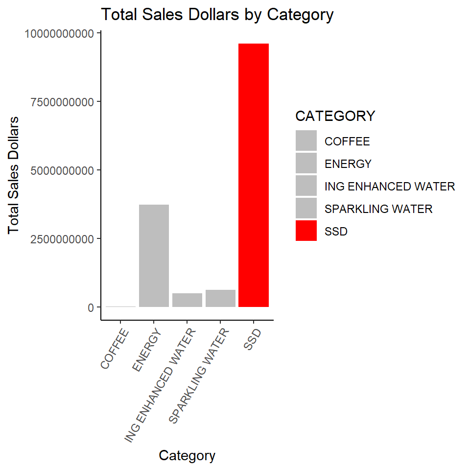

```r
ggplot(cat_summary, aes(x = CATEGORY )) +
  geom_bar(aes(y = total_sales_dollars, fill = CATEGORY), stat = "identity", position = "dodge") +
  labs(title = "Total Sales Dollars by Category",
       x = "Category",
       y = "Total Sales Dollars") +
  theme_classic() +
  scale_fill_manual(values = c( "SPARKLING WATER" = "grey", "SSD" = "red", "ING ENHANCED WATER" = "grey", "COFFEE" = "grey", "ENERGY" = "grey")) +
  theme(axis.text.x = element_text(angle = 60, hjust = 1)) +
  theme(axis.text.y = element_text(angle = 0, hjust = 1))
```

> SSD accounts for the vast majority of total sales in both units and dollars. This is likely the identifier for “soda” or soda equivalent. We can see that this is where Swire-CC makes most of their money and is the main focus of their operations. Because this is the main focus, it may make sense financially to focus on SSD products as they are the type items they have the most experience with and likely the one that they can produce in the most cost effective manner.

### Takeaway 8: Energy Drinks have the highest Average Sale Price by Category

```r
cat_up_summary <- swire_df %>%
  group_by(CATEGORY) %>%
  summarise(n = n(),
            avg_price_unit = mean(UNIT_PRICE),
            avg_sales_dollars = mean(DOLLAR_SALES),
            avg_unit_sales = mean(UNIT_SALES)
  ) %>%
  arrange(desc(avg_price_unit))

cat_up_summary
```

```
## # A tibble: 5 × 5
##   CATEGORY                  n avg_price_unit avg_sales_dollars avg_unit_sales
##   <fct>                 <int>          <dbl>             <dbl>          <dbl>
## 1 ENERGY              5932087           6.60             627.           202.
## 2 SSD                12912281           3.91             744.           209.
## 3 ING ENHANCED WATER  2452456           3.80             202.            80.4
## 4 SPARKLING WATER     3019064           3.74             208.            55.0
## 5 COFFEE               145536           2.91              99.0           45.1
```

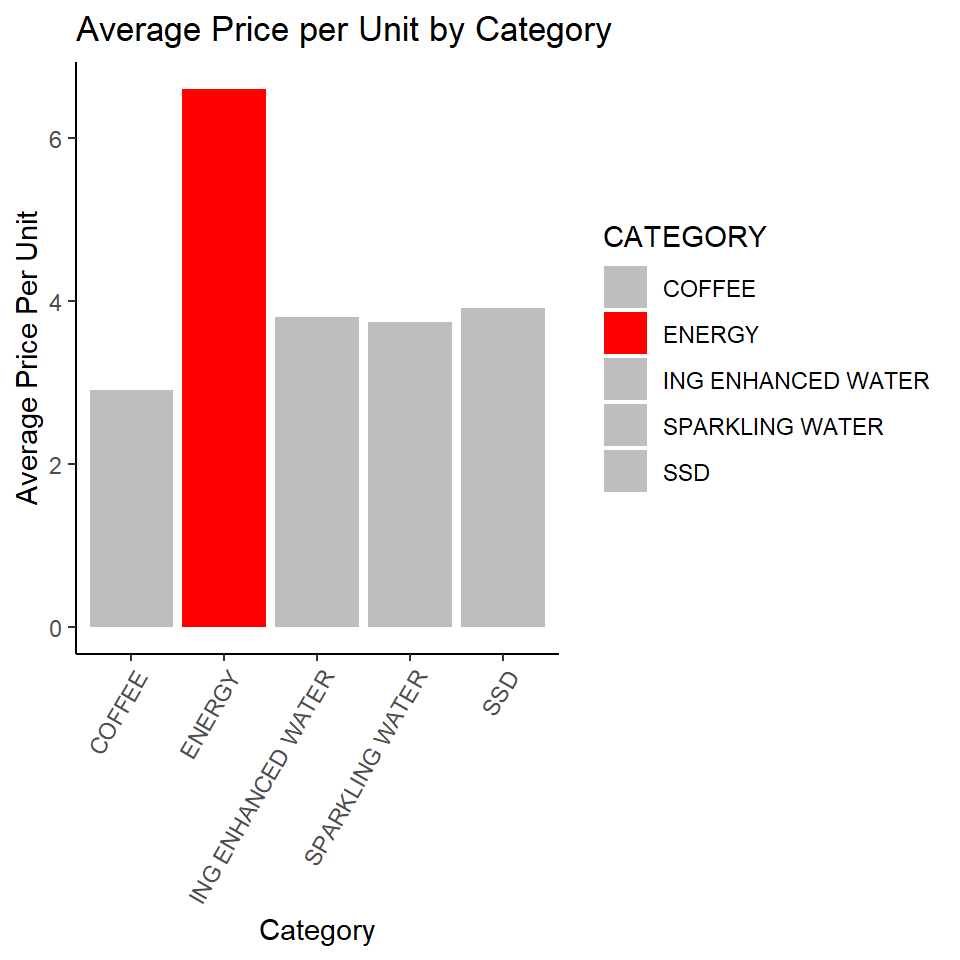

```r
ggplot(cat_up_summary, aes(x = CATEGORY )) +
  geom_bar(aes(y = avg_price_unit, fill = CATEGORY), stat = "identity", position = "dodge") +
  labs(title = "Average Price per Unit by Category",
       x = "Category",
       y = "Average Price Per Unit") +
  theme_classic() +
  scale_fill_manual(values = c( "SPARKLING WATER" = "grey", "SSD" = "grey", "ING ENHANCED WATER" = "grey", "COFFEE" = "grey", "ENERGY" = "red")) +
  theme(axis.text.x = element_text(angle = 60, hjust = 1)) +
  theme(axis.text.y = element_text(angle = 0, hjust = 1))
```

> Energy drinks appear to sell at a much higher price per unit than the other caloric segment types. This means that assuming their cost to produce is not much different from the other caloric segments, producing more energy drinks would be an easy way to increase their margin and should potentially be more of a focus.

### Takeaway 9: Potential Innovation Products - Brand and Package Combinations 1-6 Months

```r
# All Brand and Package combinations
swire_df %>%
  group_by(BRAND, PACKAGE) %>%
  summarise(MIN_DATE = min(DATE),
            MAX_DATE = max(DATE),
            DURATION = MAX_DATE - MIN_DATE) %>%
  arrange(desc(DURATION))
```

```
## # A tibble: 1,720 × 5
## # Groups:   BRAND [319]
##    BRAND                       PACKAGE            MIN_DATE   MAX_DATE   DURATION
##    <fct>                       <fct>              <date>     <date>     <drtn>
##  1 ABCS                        12SMALL 24ONE PLA… 2020-12-05 2023-10-28 1057 da…
##  2 ABCS                        12SMALL 4ONE PLAS… 2020-12-05 2023-10-28 1057 da…
##  3 ABCS                        12SMALL MLT PLAST… 2020-12-05 2023-10-28 1057 da…
##  4 ALL-OUT ALLIGATOR REAL-TIME 12SMALL 24ONE CUP  2020-12-05 2023-10-28 1057 da…
##  5 ANCESTOR PEPPY              12SMALL 12ONE CUP  2020-12-05 2023-10-28 1057 da…
##  6 ANCIENT ELIXIR              12SMALL 6ONE CUP   2020-12-05 2023-10-28 1057 da…
##  7 ANCIENT ELIXIR              2L MULTI JUG       2020-12-05 2023-10-28 1057 da…
##  8 AZURE HORIZON               12SMALL 6ONE CUP   2020-12-05 2023-10-28 1057 da…
##  9 BEAUTIFUL GREENER           .5L 6ONE JUG       2020-12-05 2023-10-28 1057 da…
## 10 BEAUTIFUL GREENER           12SMALL 12ONE CUP  2020-12-05 2023-10-28 1057 da…
## # ℹ 1,710 more rows
```

```r
# launch DATE, end DATE, and DURATION of brand or package less than 6 months, or 26 weeks, in duration
swire_df %>%
  group_by(BRAND, PACKAGE) %>%
  summarise(MIN_DATE = min(DATE),
            MAX_DATE = max(DATE),
            DURATION = MAX_DATE - MIN_DATE) %>%
  filter(DURATION < 180) %>%
  filter(DURATION > 30) %>%
  arrange(desc(DURATION))
```

```
## # A tibble: 95 × 5
## # Groups:   BRAND [78]
##    BRAND                        PACKAGE           MIN_DATE   MAX_DATE   DURATION
##    <fct>                        <fct>             <date>     <date>     <drtn>
##  1 CROWN                        ALL OTHER ONES    2023-05-06 2023-10-28 175 days
##  2 DIET BUBBLE JOY ADVANTAGEOUS 7.5SMALL 4ONE CUP 2023-05-06 2023-10-28 175 days
##  3 DIET ELF BUBBLES ZERO        7.5SMALL 4ONE CUP 2023-05-06 2023-10-28 175 days
##  4 ELF BUBBLES LYMONADE LEGACY  20SMALL MULTI JUG 2023-05-06 2023-10-28 175 days
##  5 FANTASMIC                    7.5SMALL 4ONE CUP 2023-05-06 2023-10-28 175 days
##  6 FRESH GRAPEFRUIT             7.5SMALL 4ONE CUP 2023-05-06 2023-10-28 175 days
##  7 KOOL! ZERO SUGAR             12SMALL 8ONE CUP  2022-04-16 2022-10-08 175 days
##  8 KOOL! ZERO SUGAR             7.5SMALL 4ONE CUP 2023-05-06 2023-10-28 175 days
##  9 SUPER-DUPER PUNCHED          12SMALL 6ONE CUP  2023-05-06 2023-10-28 175 days
## 10 ASTRAL BEVERAGE              .5L 12ONE JUG     2023-05-13 2023-10-28 168 days
## # ℹ 85 more rows
```

> If we define innovation products as being in the market for at least 30 days but less than 6 months, we will have 95 different brand packaging combinations that fit that criteria in our historic data set out of a total of 1720 Package and Brand Combinations

### Takeaway 10: Potential Innovation Products - Brand & Packaging Combinations ~13 Weeks

```r
swire_df %>%
  group_by(BRAND, PACKAGE) %>%
  summarise(n = n(),
            MIN_DATE = min(DATE),
            MAX_DATE = max(DATE),
            DURATION = MAX_DATE - MIN_DATE) %>%
  filter(DURATION < 100 ) %>%
  filter(DURATION > 81) %>%
  arrange(desc(DURATION))
```

```
## # A tibble: 15 × 6
## # Groups:   BRAND [15]
##    BRAND                            PACKAGE     n MIN_DATE   MAX_DATE   DURATION
##    <fct>                            <fct>   <int> <date>     <date>     <drtn>
##  1 HILL MOISTURE ZERO SUGAR COASTA… 12SMAL…    12 2023-07-15 2023-10-21 98 days
##  2 KOOL! ZERO SUGAR MOON            7.5SMA…    11 2022-02-26 2022-06-04 98 days
##  3 PAPI ZERO SUGAR                  12SMAL…     6 2022-06-25 2022-10-01 98 days
##  4 RADIANT'S                        12SMAL…    13 2022-01-22 2022-04-30 98 days
##  5 DIET HANSENIZZLE'S               12SMAL…     4 2022-11-26 2023-02-25 91 days
##  6 HILL MOISTURE ZERO SUGAR         16SMAL…     4 2021-01-09 2021-04-10 91 days
##  7 DIET BUBBLE JOY ADVANTAGEOUS     12SMAL…     4 2022-10-08 2022-12-31 84 days
##  8 DIET PEPPY                       12SMAL…     3 2022-03-26 2022-06-18 84 days
##  9 ELF BUBBLES                      8.5SMA…     2 2021-06-12 2021-09-04 84 days
## 10 ELF BUBBLES SUMMER SPICED MIXED… 12SMAL…    18 2022-10-29 2023-01-21 84 days
## 11 KOOL! ZERO SUGAR SHREK           7.5SMA…     3 2022-08-20 2022-11-12 84 days
## 12 MYTHICAL BEVERAGE REHAB          16SMAL…    10 2020-12-12 2021-03-06 84 days
## 13 PAPI WILD CHERRY                 7.5SMA…   323 2023-08-05 2023-10-28 84 days
## 14 PEPPY ZERO SUGAR                 12SMAL…    16 2023-08-05 2023-10-28 84 days
## 15 PLEASURE & LIGHT                 12SMAL…     3 2021-07-17 2021-10-09 84 days
```

> 3 of the 7 questions are related to 13 week launches 13*7 = 91 days, so here we are looking at 80-100 days to get an idea of the products that were released for roughly the same time frames as the products that Swire-CC is looking to release for 13 weeks.

# Summary and Results

> There are a lot of things that we can take away from these general summaries of the market demand datasheet.

> When analyzing the DATE column, we see roughly 3 years worth of data available. Some of the products in the data set have a DURATION of the full 3 years, while others are less than 6 months. Those that are less than 6 months will likely be the most relevant to our innovation product predictions.

> When analyzing the data, the DATE attribute will be very important and it could be useful to make subsets of our models with the data for products with different date ranges, such as 13 weeks, less than 6 months, etc to try and use data that is most similar to the questions we are trying to answer

> We see that CATEGORY while Energy Drinks are the type of drinks that they make the most money off per unit as the price is nearly twice as high as the other Categories, SSD is by far the dominant category that they sell.

> Swire-CC appears to be middle of the road in terms of the other Manfacturers in the data set when it comes to total sales in dollars and total unit sales. However, their low price per unit in comparison to other manufacturers is concerning. They are having to sell more total units to reach the same number of total dollars than other manufacturers would, which means they will incure more costs and have less profit for the same amount of total dollars sold. When doing our analysis, we will want to see if we can focus on items that have a higher average unit price

> The two different caloric segments (diet/lite vs regular) sell for roughly the same amount per unit, but they do a lot more sales both in units and total dollars of regular drinks. This indicates a higher demand for regular over diet soda.

> Overall, there are so many observations of the data that our main task will be deciding what fields to focus on and what questions to answer. Once we do that, we will be able to use the large amounts of observations to have sufficient data to field into the models that we build.